# A_1

Stefanie KObsar

4/1/2020

## El objetivo de esta actividad es realizar una puesta a punto del dataset para que el posterior análisis pueda ser quantitativo, reproducible y comparable con otras variables.

Las autoridades sanitarias desean realizar un estudio del peso al nacer de los niños y niñas nacidos en España en el último año. Para ello, han realizado un muestreo de 300 niños y niñas nacidos en distintos hospitales del país. El conjunto de datos BWn.csv contiene estos datos. La estructura del conjunto de datos es la siguiente. Cada fila corresponde a un nacimiento y para cada uno, se especifican las siguientes variables:

Id: identificador numérico. HP: nombre del hospital. City: nombre de la ciudad donde se ha producido el nacimiento. Time: hora del nacimiento (valor entre 0 y 24). Day: día de la semana (valor entre 1 y 7). BW: peso al nacer. BPD: diámetro biparietal (en mm), determinado por ultrasonidos, medido antes de nacer. AD: diámetro abdominal (en mm), determinado por ultrasonidos, medido antes de nacer. Sex: sexo del bebé. Ge: semanas de gestación. Sm: si la madre es fumadora (’S’ en caso afirmativo, ’N’ en caso negativo).

```r
df_BWn <- read.csv("BWn.csv", sep=";")
head(df_BWn)
```

```
##   ID                           HP      City  Time Day       BW   BPD
## 1  1 H.G.U.Gregorio Mara\xf1\xf3n  valencia 13,34   5  2.2  kg 82 mm
## 2  2             H.U.de Bellvitge Barcelona    11   1 4100  gr 97 mm
## 3  3             H.U.de Bellvitge    Madrid    24   2  4.2  kg 97 mm
## 4  4                  H.Cl\xednic Barcelona 18,64   4 1300  gr 74 mm
## 5  5            H.U.12 de octubre    Madrid  9,89   3 1150  gr 68 mm
## 6  6 H.G.U.Gregorio Mara\xf1\xf3n    Madrid  5,68   6 3400  gr 94 mm
##       AD  Sex   Ge Sm
## 1  90 mm    M 32,8  N
## 2 129 mm    M 43,2  N
## 3 133 mm    F 43,2  N
## 4  71 mm    M   33  S
## 5  80 mm girl   33  S
## 6 110 mm    F 39,2  N
```

Los criterios a aplicar para este preproceso son:

*Los nombres de las ciudades empiezan con una letra mayúscula y van seguidos por letras minúsculas.

*Los nombres de los hospitales estandarizados son los que aparecen en la lista que se muestra más adelante. Cualquier variación sobre estos nombres debe normalizarse.

*Se proporciona además una lista de los hospitales y de las ciudades a los que corresponden. En caso de inconstistencias, prevalece el dato del hospital y por tanto, la ciudad se modifica para adecuarse.

*En variables cuantitativas continuas, el símbolo para expresar la coma decimal es el punto.

*El tiempo, expresado como un valor numérico de 0 a 24, debe expresarse como HH:MM. No es necesario guardar el valor de los segundos.

*Los días de la semana deben ser: Lunes, Martes, Miércoles, Jueves, Viernes, Sábado, Domingo. En el fichero, el número 1 corresponde a Lunes y consecutivamente hasta el 7 que corresponde a Domingo.

*Deben cambiarse los valores numéricos por el nombre del día.

*El peso (variable BW) debe expresarse de forma numérica y en gramos. Por ejemplo, los valores del tipo “3.300gr” o “3.3kg” deben guardarse como un dato numérico de valor 3300.

*Los valores de diámetro biparietal y abdominal deben expresarse en milímetros y las variables deben ser numéricas. En caso que el formato de los datos sean de tipo carácter, debe transformarse a numérico para su posterior análisis.

*El sexo debe codificarse como “F” para referirse a femenino y “M” masculino.

*Las semanas de gestación deben redondearse al valor entero más próximo.

*En caso de realizar cambios sobre los datos, éstos deben ser identificados y explicados en el informe.

```r
#library(tidyverse)

cities <- df_BWn$City
head(cities)#vector of integers
```

```
## [1] valencia  Barcelona Madrid    Barcelona Madrid    Madrid
## 8 Levels: Barcelona Granada Madrid Pamplona sevilla Sevilla ... Valencia
```

```r
cities_char <- as.character(cities)
cities_capital <- stringr::str_to_title(cities_char)
head(cities_capital)
```

```
## [1] "Valencia"  "Barcelona" "Madrid"    "Barcelona" "Madrid"    "Madrid"
```

```r
cities_char <- as.character(cities)
cities_capital <- stringr::str_to_title(cities_char)
head(cities_capital)
```

```
## [1] "Valencia"  "Barcelona" "Madrid"    "Barcelona" "Madrid"    "Madrid"
```

```r
df_BWn["City"] <- cities_capital
head(df_BWn)
```

```
##   ID                           HP      City  Time Day       BW   BPD
## 1  1 H.G.U.Gregorio Mara\xf1\xf3n  Valencia 13,34   5  2.2  kg 82 mm
## 2  2             H.U.de Bellvitge Barcelona    11   1 4100  gr 97 mm
## 3  3             H.U.de Bellvitge    Madrid    24   2  4.2  kg 97 mm
## 4  4                  H.Cl\xednic Barcelona 18,64   4 1300  gr 74 mm
## 5  5            H.U.12 de octubre    Madrid  9,89   3 1150  gr 68 mm
## 6  6 H.G.U.Gregorio Mara\xf1\xf3n    Madrid  5,68   6 3400  gr 94 mm
##       AD  Sex   Ge Sm
## 1  90 mm    M 32,8  N
## 2 129 mm    M 43,2  N
## 3 133 mm    F 43,2  N
## 4  71 mm    M   33  S
## 5  80 mm girl   33  S
## 6 110 mm    F 39,2  N
```

NOMBRES ESTANDARIZADOS DE LOS HOSPITALES:

H.U.La Paz = Madrid H.Clínic = Barcelona H.U.Vall d’Hebron = Barcelona H.U.12 de octubre = Madrid H.G.U.Gregorio Marañón = Madrid H.U.Politècnic La Fe = Valencia H.U.Quirón Dexeus = Barcelona C.U.Navarra = Pamplona H.U.de Bellvitge = Barcelona H.M.I. Virgen de las Nieves = Granada H.U.Virgen del Rocío = Sevilla

```r
list_HP <- as.character(df_BWn$HP)
len_list_HP <- c(1:length(list_HP))

for (i in len_list_HP) {
  if (list_HP[i] == "H.G.U.Gregorio Mara\xf1\xf3n" ) {
  list_HP[i] <- "H.G.U.Gregorio Marañón"
  }
  if (list_HP[i] == "H.U.Quir\xf3n Dexeus" ) {
  list_HP[i] <- "H.U.Quirón Dexeus"
  }
  if (list_HP[i] == "H.U.Quir\xf3n Dexeus" ) {
  list_HP[i] <- "H.U.Quirón Dexeus"
  }
  if (list_HP[i] == "H.U.Polit\xe8cnic La Fe" ) {
  list_HP[i] <- "H.U.Politècnic La Fe"
  }
  if (list_HP[i] == "H.Cl\xednic" ) {
  list_HP[i] <- "H.Clínic"
  }
  if (list_HP[i] == "H.U.Virgen del Roc\xedo" ) {
  list_HP[i] <- "H.U.Virgen del Rocío"
  }

}

df_BWn["HP"] <- list_HP
head(df_BWn)
```

```
##   ID                     HP      City  Time Day       BW   BPD     AD  Sex
## 1  1 H.G.U.Gregorio Marañón  Valencia 13,34   5  2.2  kg 82 mm  90 mm    M
## 2  2       H.U.de Bellvitge Barcelona    11   1 4100  gr 97 mm 129 mm    M
## 3  3       H.U.de Bellvitge    Madrid    24   2  4.2  kg 97 mm 133 mm    F
## 4  4               H.Clínic Barcelona 18,64   4 1300  gr 74 mm  71 mm    M
## 5  5      H.U.12 de octubre    Madrid  9,89   3 1150  gr 68 mm  80 mm girl
## 6  6 H.G.U.Gregorio Marañón    Madrid  5,68   6 3400  gr 94 mm 110 mm    F
##     Ge Sm
## 1 32,8  N
## 2 43,2  N
## 3 43,2  N
## 4   33  S
## 5   33  S
## 6 39,2  N
```

```r
#En variables cuantitativas continuas, el símbolo para expresar la coma decimal es el punto.

time <- df_BWn$Time
Ge <- df_BWn$Ge

time_dot <- as.numeric(gsub(",", ".", gsub("\\.", "", time)))
Ge_dot <- as.numeric(gsub(",", ".", gsub("\\.", "", Ge)))

df_BWn["Time"] <- time_dot
df_BWn["Ge"] <- Ge_dot
head(df_BWn)
```

```
##   ID                     HP      City  Time Day       BW   BPD     AD  Sex
## 1  1 H.G.U.Gregorio Marañón  Valencia 13.34   5  2.2  kg 82 mm  90 mm    M
## 2  2       H.U.de Bellvitge Barcelona 11.00   1 4100  gr 97 mm 129 mm    M
## 3  3       H.U.de Bellvitge    Madrid 24.00   2  4.2  kg 97 mm 133 mm    F
## 4  4               H.Clínic Barcelona 18.64   4 1300  gr 74 mm  71 mm    M
## 5  5      H.U.12 de octubre    Madrid  9.89   3 1150  gr 68 mm  80 mm girl
## 6  6 H.G.U.Gregorio Marañón    Madrid  5.68   6 3400  gr 94 mm 110 mm    F
##     Ge Sm
## 1 32.8  N
## 2 43.2  N
## 3 43.2  N
## 4 33.0  S
## 5 33.0  S
## 6 39.2  N
```

```r
#El tiempo, expresado como un valor numérico de 0 a 24, debe expresarse como HH:MM. No es necesario guardar el valor de los segundos.
time <- (df_BWn$Time)
df_BWn$Time <- format(as.POSIXct((time) * 86400, origin = "1970-01-01", tz = "UTC"), "%H:%M")
head(df_BWn)
```

```
##   ID                     HP      City  Time Day       BW   BPD     AD  Sex
## 1  1 H.G.U.Gregorio Marañón  Valencia 08:09   5  2.2  kg 82 mm  90 mm    M
## 2  2       H.U.de Bellvitge Barcelona 00:00   1 4100  gr 97 mm 129 mm    M
## 3  3       H.U.de Bellvitge    Madrid 00:00   2  4.2  kg 97 mm 133 mm    F
## 4  4               H.Clínic Barcelona 15:21   4 1300  gr 74 mm  71 mm    M
## 5  5      H.U.12 de octubre    Madrid 21:21   3 1150  gr 68 mm  80 mm girl
## 6  6 H.G.U.Gregorio Marañón    Madrid 16:19   6 3400  gr 94 mm 110 mm    F
##     Ge Sm
## 1 32.8  N
## 2 43.2  N
## 3 43.2  N
## 4 33.0  S
## 5 33.0  S
## 6 39.2  N
```

```r
#Los días de la semana deben ser: Lunes, Martes, Miércoles, Jueves, Viernes, Sábado, Domingo. En el fichero, el número 1 corresponde a Lunes y consecutivamente hasta el 7 que corresponde a Domingo.

list_day <- df_BWn$Day
len_list_day <- c(1:length(list_day))

for (i in len_list_day) {
  if (list_day[i] == 1) {
  list_day[i] <- "Lunes"
  }
  if (list_day[i] == 2 ) {
  list_day[i] <- "Martes"
  }
  if (list_day[i] == 3 ) {
  list_day[i] <- "Miércoles"
  }
  if (list_day[i] == 4 ) {
  list_day[i] <- "Jueves"
  }
  if (list_day[i] == 5 ) {
  list_day[i] <- "Viernes"
  }
  if (list_day[i] == 6 ) {
  list_day[i] <- "Sábado"
  }
  if (list_day[i] == 7 ) {
  list_day[i] <- "Domingo"
  }

}

df_BWn["Day"] <- list_day
head(df_BWn)
```

```
##   ID                     HP      City  Time       Day       BW   BPD
## 1  1 H.G.U.Gregorio Marañón  Valencia 08:09   Viernes  2.2  kg 82 mm
## 2  2       H.U.de Bellvitge Barcelona 00:00     Lunes 4100  gr 97 mm
## 3  3       H.U.de Bellvitge    Madrid 00:00    Martes  4.2  kg 97 mm
## 4  4               H.Clínic Barcelona 15:21    Jueves 1300  gr 74 mm
## 5  5      H.U.12 de octubre    Madrid 21:21 Miércoles 1150  gr 68 mm
## 6  6 H.G.U.Gregorio Marañón    Madrid 16:19    Sábado 3400  gr 94 mm
##       AD  Sex   Ge Sm
## 1  90 mm    M 32.8  N
## 2 129 mm    M 43.2  N
## 3 133 mm    F 43.2  N
## 4  71 mm    M 33.0  S
## 5  80 mm girl 33.0  S
## 6 110 mm    F 39.2  N
```

```r
#El peso (variable BW) debe expresarse de forma numérica y en gramos. Por ejemplo, los valores del tipo "3.300gr" o "3.3kg" deben guardarse como un dato numérico de valor 3300.

BW <-df_BWn$BW
BW_kg <- gsub("kg","", as.factor(factor(BW)) )
BW_kg_gr <- gsub("gr", "", as.factor(factor(BW_kg)) )
BW_mod <- BW_kg_gr

df_BWn["BW"] <- BW_mod
head(df_BWn)
```

```
##   ID                     HP      City  Time       Day     BW   BPD     AD
## 1  1 H.G.U.Gregorio Marañón  Valencia 08:09   Viernes  2.2   82 mm  90 mm
## 2  2       H.U.de Bellvitge Barcelona 00:00     Lunes 4100   97 mm 129 mm
## 3  3       H.U.de Bellvitge    Madrid 00:00    Martes  4.2   97 mm 133 mm
## 4  4               H.Clínic Barcelona 15:21    Jueves 1300   74 mm  71 mm
## 5  5      H.U.12 de octubre    Madrid 21:21 Miércoles 1150   68 mm  80 mm
## 6  6 H.G.U.Gregorio Marañón    Madrid 16:19    Sábado 3400   94 mm 110 mm
##    Sex   Ge Sm
## 1    M 32.8  N
## 2    M 43.2  N
## 3    F 43.2  N
## 4    M 33.0  S
## 5 girl 33.0  S
## 6    F 39.2  N
```

```r
#Los valores de diámetro biparietal y abdominal deben expresarse en milímetros y las variables deben ser numéricas. En caso que el formato de los datos sean de tipo carácter, debe transformarse a numérico para su posterior análisis.
bpd <-df_BWn$BPD
bpd_mod <- gsub("mm", "", paste(bpd))
bpd_mod_num <- as.numeric(bpd_mod)
df_BWn["BPD"] <- bpd_mod_num

ad <-df_BWn$AD
ad_mod <- gsub("mm", "", paste(ad))
ad_mod_num <- as.numeric(ad_mod)
df_BWn["AD"] <- ad_mod_num

head(df_BWn)
```

```
##   ID                     HP      City  Time       Day     BW BPD  AD  Sex
## 1  1 H.G.U.Gregorio Marañón  Valencia 08:09   Viernes  2.2    82  90    M
## 2  2       H.U.de Bellvitge Barcelona 00:00     Lunes 4100    97 129    M
## 3  3       H.U.de Bellvitge    Madrid 00:00    Martes  4.2    97 133    F
## 4  4               H.Clínic Barcelona 15:21    Jueves 1300    74  71    M
## 5  5      H.U.12 de octubre    Madrid 21:21 Miércoles 1150    68  80 girl
## 6  6 H.G.U.Gregorio Marañón    Madrid 16:19    Sábado 3400    94 110    F
##     Ge Sm
## 1 32.8  N
## 2 43.2  N
## 3 43.2  N
## 4 33.0  S
## 5 33.0  S
## 6 39.2  N
```

```r
#El sexo debe codificarse como "F" para referirse a femenino y "M" masculino.

sex <- df_BWn$Sex
sex
```

```
##   [1] M    M    F    M    girl F    fem  F    F    fem  M    F    F    f
##  [15] F    girl M    F    boy  boy  M    M    F    F    M    M    boy  F
##  [29] M    F    M    M    F    M    F    F    M    girl M    boy  M    F
##  [43] M    M    M    M    F    M    M    boy  M    M    F    boy  F    F
##  [57] F    M    M    F    M    M    M    M    M    F    M    F    F    F
##  [71] F    M    F    F    f    M    boy  fem  F    F    M    F    M    girl
##  [85] F    M    F    F    M    F    boy  F    boy  boy  F    F    f    M
##  [99] F    boy  F    girl F    f    F    F    M    M    F    boy  M    M
## [113] boy  F    M    M    M    F    F    boy  M    M    M    F    M    F
## [127] F    F    girl fem  M    F    M    M    M    F    F    F    f    fem
## [141] M    F    fem  fem  F    F    F    F    fem  F    M    F    F    M
## [155] M    M    F    F    F    F    F    F    F    F    M    F    M    M
## [169] M    F    M    M    M    F    F    M    F    F    M    F    F    M
## [183] F    F    M    F    F    M    F    M    M    M    M    M    F    F
## [197] F    F    F    F    M    M    M    M    F    M    M    F    F    M
## [211] F    F    M    F    M    F    M    M    F    F    M    F    M    M
## [225] F    F    F    F    M    F    F    F    M    F    F    F    F    F
## [239] F    F    F    F    F    M    M    M    F    F    M    F    F    F
## [253] F    F    F    F    F    M    M    F    M    F    M    F    M    M
## [267] M    M    M    F    F    F    M    M    F    F    F    F    F    M
## [281] M    M    F    F    F    M    M    F    F    M    F    M    M    F
## [295] M    M    F    F    F    M
## Levels: boy f F fem girl M
```

```r
list_sex <- df_BWn$Sex
len_list_sex <- c(1:length(list_sex))

for (i in len_list_sex) {
  if (list_sex[i] == "girl" | list_sex[i] == "f" | list_sex[i] == "fem") {
    list_sex[i] <- "F"
  }
  if (list_sex[i] == "boy" | list_sex[i] == "m") {
    list_sex[i] <- "M"
  }
}

df_BWn["Sex"] <- list_sex
df_BWn$Sex
```

```
##   [1] M M F M F F F F F F M F F F F F M F M M M M F F M M M F M F M M F M F
##  [36] F M F M M M F M M M M F M M M M M F M F F F M M F M M M M M F M F F F
##  [71] F M F F F M M F F F M F M F F M F F M F M F M M F F F M F M F F F F F
## [106] F M M F M M M M F M M M F F M M M M F M F F F F F M F M M M F F F F F
## [141] M F F F F F F F F F M F F M M M F F F F F F F F M F M M M F M M M F F
## [176] M F F M F F M F F M F F M F M M M M M F F F F F F M M M M F M M F F M
## [211] F F M F M F M M F F M F M M F F F F M F F F M F F F F F F F F F F M M
## [246] M F F M F F F F F F F F M M F M F M F M M M M M F F F M M F F F F F M
## [281] M M F F F M M F F M F M M F M M F F F M
## Levels: boy f F fem girl M
```

```r
#Las semanas de gestación deben redondearse al valor entero más próximo.
ge <- df_BWn$Ge
ge_round <- format(ge, digits = 2)
df_BWn["Ge"] <- as.numeric(ge_round)
head(df_BWn)
```

```
##   ID                     HP      City  Time       Day     BW BPD  AD Sex
## 1  1 H.G.U.Gregorio Marañón  Valencia 08:09   Viernes  2.2    82  90   M
## 2  2       H.U.de Bellvitge Barcelona 00:00     Lunes 4100    97 129   M
## 3  3       H.U.de Bellvitge    Madrid 00:00    Martes  4.2    97 133   F
## 4  4               H.Clínic Barcelona 15:21    Jueves 1300    74  71   M
## 5  5      H.U.12 de octubre    Madrid 21:21 Miércoles 1150    68  80   F
## 6  6 H.G.U.Gregorio Marañón    Madrid 16:19    Sábado 3400    94 110   F
##   Ge Sm
## 1 33  N
## 2 43  N
## 3 43  N
## 4 33  S
## 5 33  S
## 6 39  N
```

Analizar la presencia de valores perdidos.

```r
library(cluster)

is.na(df_BWn)
```

[output not shown]

[output cut: 286 more lines]

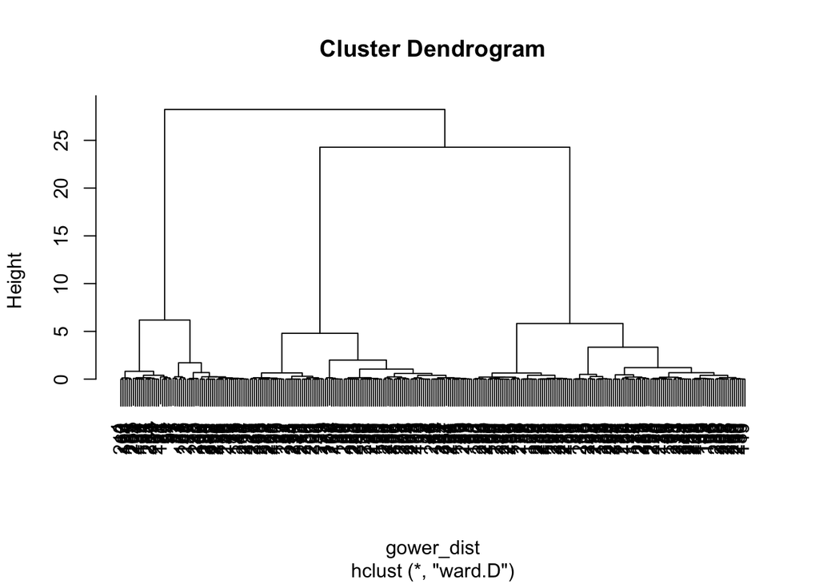

```r
#hay valores perdidos para la variable BPD y AD

df_temp <- df_BWn[, -(1:6)]
#quito también BW porque no sé como ponerlo en el formato requerido.

gower_dist <- daisy(df_temp, metric = c("gower"))

#distancia de gower media = 0,3149

#validar la distancia
hc1 <- hclust(gower_dist, method = "ward.D" )
plot(hc1)
```

```r
#se observa 3 clusters diferenciados.
```

```r
gower_dist_mat <- as.matrix(gower_dist) #matriz e distancias entre cada una de las lineas del df

#we have to divide the dat into clusters

cluster1 <- pam(gower_dist_mat, diss = TRUE, k = 3)
table(cluster1$clustering)
```

```
##
##   1   2   3
## 110 133  57
```

```r
df_temp_2 <- cbind(df_temp, cluster1$clustering)
colnames(df_temp_2)[ncol(df_temp_2)] <- c("pam_cluster")
aggregate(df_temp_2[,(1:2)], list(df_temp_2$pam_cluster), mean)
```

```
##   Group.1 BPD AD
## 1       1  NA NA
## 2       2  NA NA
## 3       3  NA NA
```

```r
library(ggplot2)

bw_box <- as.numeric(c(df_BWn$BW))
boxplot.stats(x = bw_box)
```

```
## $stats
## [1]    1.45 1450.00 2500.00 2950.00 4850.00
##
## $n
## [1] 297
##
## $conf
## [1] 2362.479 2637.521
##
## $out
## numeric(0)
```

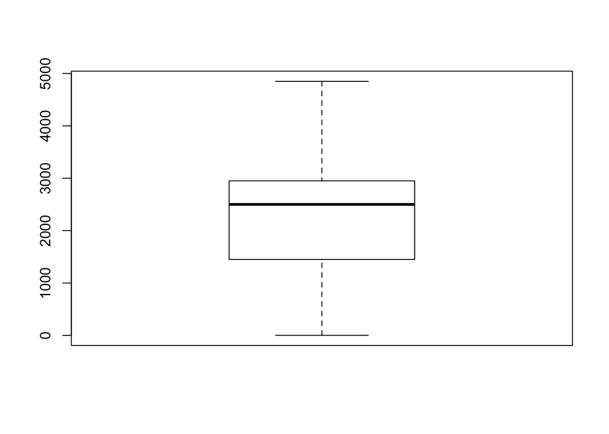

```r
boxplot(bw_box)
```

BOXPLOT:

La linea negra que se observa dentro de la caja equivale a la mediana del conjunto de datos analizado, en este caso BW. La intersección entre la linea punteada y la linea continua de los lados superior e inferior de la caja representa a su vez la mediana de los valores comprendidos entre el máximo valor y el valor de la mediana de todo el conjunto; y el mínimo valor y la mediana total, respectivamente.

Al otro extremo de la linea discontínua, se encuentra un linea continua que representa la imagen del eje vertical equivalente a los valores máximos y mínimos del conjunto de datos. Esencialmente, se divide el el conjunto de datos en 4 partes, o cuartiles.

El problema en BW es que no he podido encontrar el código para poder poner todos los valores en el mismo rango, y por tanto coexisten valores en kg y gramos en la misma secuencia de datos. Ello provoca que el boxplot sea inconsistente, ya que se están evaluando los datos en un rango incorrecto.

```r
ad_box <- as.numeric(c(df_BWn$AD))
boxplot.stats(x = ad_box)
```

```
## $stats
## [1]  73  94 102 108 129
##
## $n
## [1] 295
##
## $conf
## [1] 100.7121 103.2879
##
## $out
##  [1] 133  71 133  71  71 133 133  71 133  71
```

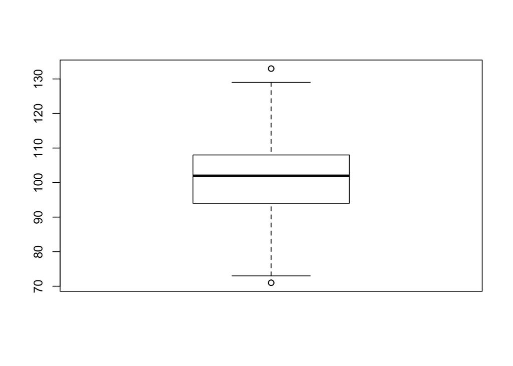

```r
boxplot(ad_box)
```

Los valores del set de datos se consideran extremos (outliers) cuando están fuera del rango en una proporción de 1.5 veces del rango formado por los cuartiles más externos. Para valorar si es correcto eliminar los ouliers, hay que evaluar si es estadísitcamente correcto. Para ello existen múltiples tests, y en este caso se usará el test de grubbs para realizar la evaluación.

```r
library(outliers)

grubbs.test(ad_box)
```

```
##
##  Grubbs test for one outlier
##
## data:  ad_box
## G = 2.75268, U = 0.97414, p-value = 0.831
## alternative hypothesis: highest value 133 is an outlier
```

```r
# TABLA CON VARIABLES CUALITATIVAS

#Variables cualitativas de df_BWn: ID, HP, City, Time, Day

df_cuali <- df_BWn[, (2:5)]
library(Hmisc)
Hmisc::describe(df_cuali)
```

```
## df_cuali
##
##  4  Variables      300  Observations
## ---------------------------------------------------------------------------
## HP
##        n  missing distinct
##      300        0       11
##
## lowest : C.U.Navarra                 H.Clínic                    H.G.U.Gregorio Marañón      H.M.I. Virgen de las Nieves H.U.12 de octubre
## highest: H.U.La Paz                  H.U.Politècnic La Fe        H.U.Quirón Dexeus           H.U.Vall d'Hebron           H.U.Virgen del Rocío
##
## C.U.Navarra (27, 0.090), H.Clínic (25, 0.083), H.G.U.Gregorio Marañón (27,
## 0.090), H.M.I. Virgen de las Nieves (30, 0.100), H.U.12 de octubre (26,
## 0.087), H.U.de Bellvitge (40, 0.133), H.U.La Paz (18, 0.060),
## H.U.Politècnic La Fe (31, 0.103), H.U.Quirón Dexeus (36, 0.120), H.U.Vall
## d'Hebron (26, 0.087), H.U.Virgen del Rocío (14, 0.047)
## ---------------------------------------------------------------------------
## City
##        n  missing distinct
##      300        0        6
##
## lowest : Barcelona Granada   Madrid    Pamplona  Sevilla
## highest: Granada   Madrid    Pamplona  Sevilla   Valencia
##
## Value      Barcelona   Granada    Madrid  Pamplona   Sevilla  Valencia
## Frequency        124        28        71        27        15        35
## Proportion     0.413     0.093     0.237     0.090     0.050     0.117
## ---------------------------------------------------------------------------
## Time
##        n  missing distinct
##      300        0      100
##
## lowest : 00:00 00:14 00:28 00:57 01:12, highest: 22:48 23:02 23:16 23:31 23:45
## ---------------------------------------------------------------------------
## Day
##        n  missing distinct
##      300        0        7
##
## lowest : Domingo   Jueves    Lunes     Martes    Miércoles
## highest: Lunes     Martes    Miércoles Sábado    Viernes
##
## Value        Domingo    Jueves     Lunes    Martes Miércoles    Sábado
## Frequency         26        41        33        43        45        53
## Proportion     0.087     0.137     0.110     0.143     0.150     0.177
##
## Value        Viernes
## Frequency         59
## Proportion     0.197
## ---------------------------------------------------------------------------
```

```r
#Variables cuantitativas: BW BPD  AD Sex Ge Sm

library(Hmisc)
df_cuanti <- df_BWn[, (6:11)]
Hmisc::describe(df_cuanti)
```

```
## df_cuanti
##
##  6  Variables      300  Observations
## ---------------------------------------------------------------------------
## BW
##        n  missing distinct
##      300        0       91
##
## lowest : 1.45    1.65    1.7     1.804   1025
## highest: 4.85    4000    4100    4200    4850
## ---------------------------------------------------------------------------
## BPD
##        n  missing distinct     Info     Mean      Gmd      .05      .10
##      290       10       23    0.994    88.98    6.503     76.7     81.0
##      .25      .50      .75      .90      .95
##     87.0     91.0     93.0     95.0     96.0
##
## lowest :  64  68  72  74  80, highest:  94  95  96  97 100
## ---------------------------------------------------------------------------
## AD
##        n  missing distinct     Info     Mean      Gmd      .05      .10
##      295        5       39    0.997    101.1     12.8     80.0     87.2
##      .25      .50      .75      .90      .95
##     94.0    102.0    108.0    114.6    118.0
##
## lowest :  71  73  78  79  80, highest: 118 119 120 129 133
## ---------------------------------------------------------------------------
## Sex
##        n  missing distinct
##      300        0        2
##
## Value         F    M
## Frequency   168  132
## Proportion 0.56 0.44
## ---------------------------------------------------------------------------
## Ge
##        n  missing distinct     Info     Mean      Gmd
##      300        0        9    0.967    36.24    3.475
##
## lowest : 33 34 36 37 38, highest: 38 39 40 41 43
##
## Value         33    34    36    37    38    39    40    41    43
## Frequency     80    59    36    21    43    16     7    10    28
## Proportion 0.267 0.197 0.120 0.070 0.143 0.053 0.023 0.033 0.093
## ---------------------------------------------------------------------------
## Sm
##        n  missing distinct
##      300        0        2
##
## Value          N     S
## Frequency    238    62
## Proportion 0.793 0.207
## ---------------------------------------------------------------------------
```